# Data Analysis Recipe Site Traffic

# 1. Data Validation

Describe validation and cleaning steps for every column in the data

## 1.1 Information about the Data:

`recipe` - Nominal. This field serves as a unique identifier for each recipe. It is not possible to have missing values for this field due to the structure of the database.

`calories` - Discrete. Represents the calorie count of a recipe. In case of missing values, the mean value of the specified category is used for filling.

`carbohydrate` - Discrete. Indicates the quantity of carbohydrates in grams in a recipe. Missing values are imputed with the mean value of the designated category.

`sugar` - Discrete. Denotes the amount of sugar in grams present in a recipe. Missing values are replaced with the computed mean value of the relevant category.

`protein` - Discrete. Represents the protein content in grams of a recipe. If values are missing, they are substituted with the mean value of the specified category.

`category` - Nominal. This field categorizes recipes into ten distinct groups, denoted by descriptive names. The original names have been substituted with corresponding names.

`servings` - Discrete. Signifies the number of servings a recipe is intended to provide.

`high_traffic` - Nominal. Describes the level of traffic with two possible values: "High" and "Null". Instances where the value was "Null" have been replaced with "Low".

```python
# Importing libraries
import pandas as pd
import seaborn as sns
import numpy as np

import matplotlib.pyplot as plt
import matplotlib.style as style
import seaborn as sns

sns.set(style="whitegrid")
sns.set_theme(style="whitegrid")
sns.color_palette("Set3")

# Read csv file into a pandas dataframe
df_recipe_copy = pd.read_csv('recipe_site_traffic_2212.csv')

# a. State whether the values match the description given in the table above.
df_recipe = df_recipe_copy.copy()
# First step is to check and understand the data.
df_recipe = df_recipe[['recipe', 'servings', 'category', 'calories', 'carbohydrate', 'sugar',  'protein', 'high_traffic']]

df_recipe.head()
```

|  | recipe | servings | category | calories | carbohydrate | sugar | protein | high_traffic |
| --- | --- | --- | --- | --- | --- | --- | --- | --- |
| 0 | 1 | 6 | Pork | NaN | NaN | NaN | NaN | High |
| 1 | 2 | 4 | Potato | 35.48 | 38.56 | 0.66 | 0.92 | High |
| 2 | 3 | 1 | Breakfast | 914.28 | 42.68 | 3.09 | 2.88 | NaN |
| 3 | 4 | 4 | Beverages | 97.03 | 30.56 | 38.63 | 0.02 | High |
| 4 | 5 | 4 | Beverages | 27.05 | 1.85 | 0.80 | 0.53 | NaN |

```python
# Data Validation:
# recipe. Numeric, unique identifier of recipe.

# Calculate the mean of each category for the specified columns
mean_values = df_recipe.groupby('category')['calories', 'protein', 'sugar', 'carbohydrate'].transform('mean')

# Fill the missing values in the specified columns with the computed mean values
df_recipe[['calories', 'protein', 'sugar', 'carbohydrate']] = df_recipe[['calories', 'protein', 'sugar', 'carbohydrate']].fillna(mean_values)

# category Character, type of recipe. Recipes are listed in one of ten possible groupings ('Lunch/Snacks', 'Beverages', 'Potato', 'Vegetable', 'Meat', 'Chicken', 'Pork', 'Dessert', 'Breakfast', 'One Dish Meal').
df_recipe['category'] = df_recipe['category'].replace({'Chicken Breast':'Chicken'})

# servings Numeric, number of servings for the recipe.
df_recipe['servings'] = df_recipe['servings'].replace({'4 as a snack': '4', '6 as a snack': '6'}).astype(str).fillna(0).astype(float)

# high_traffic Character, if the traffic to the site was high when this recipe was shown, this is marked with “High”.
df_recipe['high_traffic'] = df_recipe['high_traffic'].fillna(0).replace(0, 'Low')

# Order Categories
ordered_cats = {"category":['Lunch/Snacks', 'Beverages', 'Potato', 'Vegetable', 'Meat', 'Chicken', 'Pork', 'Dessert', 'Breakfast', 'One Dish Meal'],
               "high_traffic": ['High', 'Low']}

df_recipe['category'].sort_values()

# Loop through DataFrame columns to efficiently change data types
for col in df_recipe:

    # Convert integer columns to int32
    if df_recipe[col].dtype == 'int':
        df_recipe[col] = df_recipe[col].astype('int16')

    # Convert float columns to float16
    elif df_recipe[col].dtype == 'float':
        df_recipe[col] = df_recipe[col].astype('float16')

    #elif df_fitness_clean[col].dtype == 'bool':
        #df_recipe[col] = df_recipe[col].astype('bool')

    # Convert columns containing ordered categorical data to ordered categories using dict
    elif col in ordered_cats.keys():
        category = pd.CategoricalDtype(ordered_cats[col], ordered=True)
        df_recipe[col] = df_recipe[col].astype(category)

    # Convert remaining columns to standard categories
    else:
        df_recipe[col] = df_recipe[col].astype('category')

# Drop rows with 'High' and 'Low' traffic
df_recipe_high_traffic = df_recipe[df_recipe['high_traffic'] == 'High'].copy()
df_recipe_low_traffic = df_recipe[df_recipe['high_traffic'] == 'Low'].copy()

#df_recipe
df_recipe.loc[[0,23,48,89,116,122,136,149]]
```

|  | recipe | servings | category | calories | carbohydrate | sugar | protein | high_traffic |
| --- | --- | --- | --- | --- | --- | --- | --- | --- |
| 0 | 1 | 6.0 | Pork | 629.5 | 28.078125 | 8.039062 | 43.812500 | High |
| 23 | 24 | 2.0 | Meat | 584.5 | 22.156250 | 5.812500 | 40.375000 | Low |
| 48 | 49 | 4.0 | Chicken | 540.5 | 21.828125 | 5.097656 | 52.156250 | Low |
| 89 | 90 | 6.0 | Pork | 629.5 | 28.078125 | 8.039062 | 43.812500 | High |
| 116 | 117 | 6.0 | Chicken | 540.5 | 21.828125 | 5.097656 | 52.156250 | High |
| 122 | 123 | 1.0 | Beverages | 384.5 | 1.929688 | 8.601562 | 0.859863 | Low |
| 136 | 137 | 2.0 | One Dish Meal | 579.0 | 50.375000 | 6.011719 | 35.937500 | High |
| 149 | 150 | 2.0 | Potato | 425.0 | 58.156250 | 3.718750 | 8.570312 | High |

```python
# Check the data types in the columns. Check the missing values in the columns
df_recipe.info()
```

```
<class 'pandas.core.frame.DataFrame'>
RangeIndex: 947 entries, 0 to 946
Data columns (total 8 columns):
 #   Column        Non-Null Count  Dtype
---  ------        --------------  -----
 0   recipe        947 non-null    int16
 1   servings      947 non-null    float16
 2   category      947 non-null    category
 3   calories      947 non-null    float16
 4   carbohydrate  947 non-null    float16
 5   sugar         947 non-null    float16
 6   protein       947 non-null    float16
 7   high_traffic  947 non-null    category
dtypes: category(2), float16(5), int16(1)
memory usage: 13.6 KB
```

# 2. Exploratory Analysis

Include two different graphics showing single variables only to demonstrate the characteristics of data. Include at least one graphic showing two or more variables to represent the relationship between features. Describe your findings.

The following highlight the complex interplay between category popularity, user engagement, and different traffic levels. The insights can guide content strategies, helping creators adapt their content based on the performance of different categories across varying traffic conditions.

### 2.1 Categories with "High" Traffic

The graph shows how many people visit different recipe categories on the website. This helps us decide which recipes to focus on and which ones people like the most.

### 2.1.1 High Traffic Categories:

**Chicken** contribute to 12.7% of high traffic recipesit, also appears in a significant number of low traffic recipes (17.2%), indicating that its popularity doesn't guarantee consistent engagement.

Meat, Dessert, and One Dish Meal each represent around 10% of high traffic recipes. Breakfast and Beverages have comparatively lower popularity, with 5.7% and 0.9% respectively.

### 2.1.2 Low Traffic Categories:

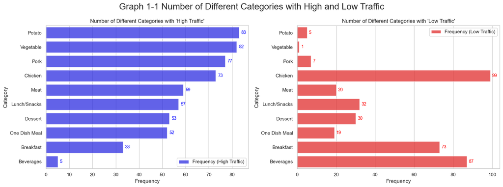

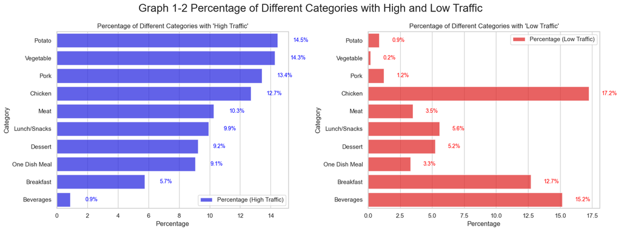

```python
# Include two different graphics showing single variables only to demonstrate the characteristics of data
# Visualization 1:

# Define the desired order of categories
desired_order = ['Potato', 'Vegetable', 'Pork', 'Chicken', 'Meat', 'Lunch/Snacks', 'Dessert', 'One Dish Meal', 'Breakfast', 'Beverages']

# Calculate the frequency of counts for each category
traffic_counts = df_recipe_high_traffic['category'].value_counts().reindex(desired_order, fill_value=0)
traffic_counts_low = df_recipe_low_traffic['category'].value_counts().reindex(desired_order, fill_value=0)

# Calculate the percentage of counts for each category
percentage_counts = traffic_counts / len(df_recipe_high_traffic) * 100
percentage_counts_low = traffic_counts_low / len(df_recipe_high_traffic) * 100

# Create bar plots for both high and low traffic by category
traffic_counts_high = df_recipe_high_traffic['category'].value_counts().loc[desired_order]
traffic_counts_low = df_recipe_low_traffic['category'].value_counts().loc[desired_order]

# Create a horizontal bar plot to show the number of different categories with high and low traffic
fig, axes = plt.subplots(1, 2, figsize=(16, 6))
plt.suptitle('Graph 1-1 Number of Different Categories with High and Low Traffic', fontsize=20)

# Create a horizontal bar plot to show the number of different categories with high traffic
sns.barplot(ax=axes[0], x=traffic_counts.values, y=traffic_counts.index, label='Frequency (High Traffic)', color='blue', alpha=0.7, order=desired_order)
# Display traffic counts on top of the bars for high traffic
for index, value in enumerate(traffic_counts_high.values):
    axes[0].text(value + 1, index, str(value), va='center', color='blue', fontsize=10)  # Display on top of blue bars
axes[0].set_title("Number of Different Categories with 'High Traffic'")
axes[0].set_xlabel("Frequency")
axes[0].set_ylabel("Category")
axes[0].legend()

# Create a horizontal bar plot to show the number of different categories with low traffic (underneath the high traffic bars)
sns.barplot(ax=axes[1], x=traffic_counts_low.values, y=traffic_counts_low.index, label='Frequency (Low Traffic)', color='red', alpha=0.7, order=desired_order)
# Display traffic counts on top of the bars for low traffic
for index, value in enumerate(traffic_counts_low.values):
    axes[1].text(value + 1, index, str(value), va='center', color='red', fontsize=10)  # Display on top of red bars
axes[1].set_title("Number of Different Categories with 'Low Traffic'")
axes[1].set_xlabel("Frequency")
axes[1].set_ylabel("Category")
axes[1].legend()

plt.tight_layout()
plt.show()

# Include two different graphics showing single variables only to demonstrate the characteristics of data
# Visualization 2:

# Create a figure with two subplots
fig, axes = plt.subplots(1, 2, figsize=(16, 6))
plt.suptitle('Graph 1-2 Percentage of Different Categories with High and Low Traffic', fontsize=20)

# Create a horizontal bar plot to show the percentage of different categories with high traffic
sns.barplot(ax=axes[0], x=percentage_counts.values, y=percentage_counts.index, label='Percentage (High Traffic)', color='blue', alpha=0.7, order=desired_order)
# Display percentages on the right side of the bars
for index, value in enumerate(percentage_counts.values):
    axes[0].text(value + 1, index, f'{value:.1f}%', va='center', color='blue', fontsize=10)
axes[0].set_title("Percentage of Different Categories with 'High Traffic'")
axes[0].set_xlabel("Percentage")
axes[0].set_ylabel("Category")
axes[0].legend()

# Create a horizontal bar plot to show the percentage of different categories with low traffic
sns.barplot(ax=axes[1], x=percentage_counts_low.values, y=percentage_counts_low.index, label='Percentage (Low Traffic)', color='red', alpha=0.7, order=desired_order)
# Display percentages on the right side of the bars
for index, value in enumerate(percentage_counts_low.values):
    axes[1].text(value + 1, index, f'{value:.1f}%', va='center', color='red', fontsize=10)
axes[1].set_title("Percentage of Different Categories with 'Low Traffic'")
axes[1].set_xlabel("Percentage")
axes[1].set_ylabel("Category")
axes[1].legend()

plt.tight_layout()
plt.show()
```

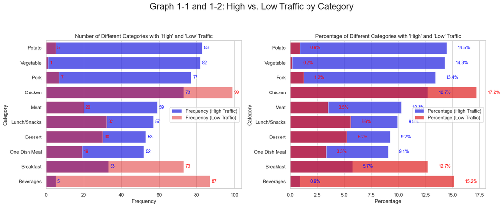

```python
# Define the desired order of categories
desired_order = ['Potato', 'Vegetable', 'Pork', 'Chicken', 'Meat', 'Lunch/Snacks', 'Dessert', 'One Dish Meal', 'Breakfast', 'Beverages']

# Calculate the frequency of counts and percentages for each category
traffic_counts_high = df_recipe_high_traffic['category'].value_counts().loc[desired_order]
traffic_counts_low = df_recipe_low_traffic['category'].value_counts().loc[desired_order]
percentage_counts_high = traffic_counts_high / len(df_recipe_high_traffic) * 100
percentage_counts_low = traffic_counts_low / len(df_recipe_high_traffic) * 100

# Create subplots
fig, axes = plt.subplots(2, 2, figsize=(16, 12))
plt.suptitle('Graph 1-1 and 1-2: High vs. Low Traffic by Category', fontsize=20)

# Plot 1-1: Number of Different Categories with High and Low Traffic
sns.barplot(ax=axes[0, 0], x=traffic_counts_high.values, y=traffic_counts_high.index, label='Frequency (High Traffic)', color='blue', alpha=0.7, order=desired_order)
sns.barplot(ax=axes[0, 0], x=traffic_counts_low.values, y=traffic_counts_low.index, label='Frequency (Low Traffic)', color='red', alpha=0.5, order=desired_order)
for index, value in enumerate(traffic_counts_high.values):
    axes[0, 0].text(value + 1, index, str(value), va='center', color='blue', fontsize=10)
for index, value in enumerate(traffic_counts_low.values):
    axes[0, 0].text(value + 1, index, str(value), va='center', color='red', fontsize=10)
axes[0, 0].set_title("Number of Different Categories with 'High' and 'Low' Traffic")
axes[0, 0].set_xlabel("Frequency")
axes[0, 0].set_ylabel("Category")
axes[0, 0].legend()

# Plot 1-2: Percentage of Different Categories with High and Low Traffic
sns.barplot(ax=axes[0, 1], x=percentage_counts_high.values, y=percentage_counts_high.index, label='Percentage (High Traffic)', color='blue', alpha=0.7, order=desired_order)
sns.barplot(ax=axes[0, 1], x=percentage_counts_low.values, y=percentage_counts_low.index, label='Percentage (Low Traffic)', color='red', alpha=0.7, order=desired_order)
for index, value in enumerate(percentage_counts_high.values):
    axes[0, 1].text(value + 1, index, f'{value:.1f}%', va='center', color='blue', fontsize=10)
for index, value in enumerate(percentage_counts_low.values):
    axes[0, 1].text(value + 1, index, f'{value:.1f}%', va='center', color='red', fontsize=10)
axes[0, 1].set_title("Percentage of Different Categories with 'High' and 'Low' Traffic")
axes[0, 1].set_xlabel("Percentage")
axes[0, 1].set_ylabel("Category")
axes[0, 1].legend()

# Remove empty subplots
fig.delaxes(axes[1, 0])
fig.delaxes(axes[1, 1])

plt.tight_layout(rect=[0, 0.03, 1, 0.95])
plt.show()
```

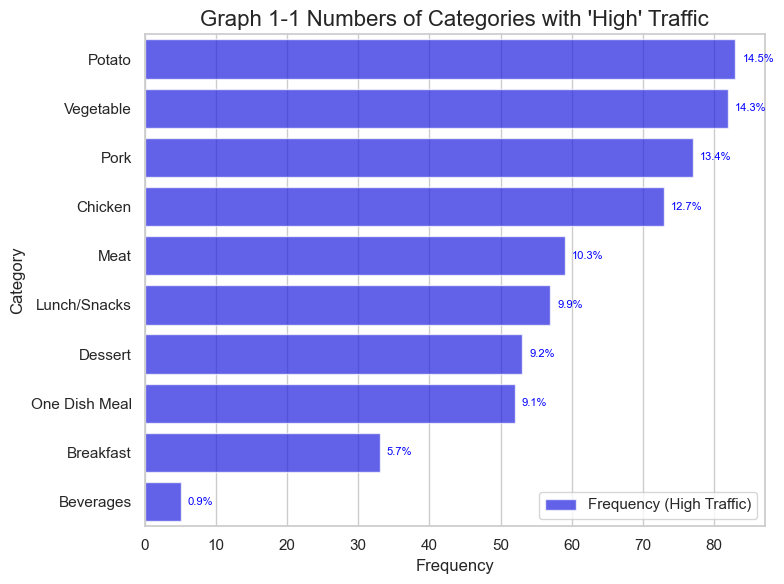

```python
# Include two different graphics showing single variables only to demonstrate the characteristics of data
# Visualization 2:

# Create a figure for the combined plot
plt.figure(figsize=(8, 6))

# Create a horizontal bar plot to show the number of different categories with high traffic
sns.barplot(x=traffic_counts.values, y=traffic_counts.index, label='Frequency (High Traffic)', color='blue', alpha=0.7, order=desired_order)

# Create a horizontal bar plot to show the number of different categories with low traffic (underneath the high traffic bars)
#sns.barplot(x=traffic_counts_low.values, y=traffic_counts_low.index, label='Frequency (Low Traffic)', color='orange', alpha=0.4, order=desired_order)

# Display percentages on the right side of the bars
for index, value in enumerate(percentage_counts.values):
    plt.text(traffic_counts.values[index] + 1, index, f'{value:.1f}%', va='center', color='blue', fontsize=8)

#for index, value in enumerate(percentage_counts_low.values):
    #plt.text(traffic_counts_low.values[index] + 1, index, f'{value:.1f}%', va='center', color='orange', fontsize=8)

#plt.title("Graph 1-1 Numbers of Categories with 'High' and 'Low' Traffic", fontsize = 16)
plt.title("Graph 1-1 Numbers of Categories with 'High' Traffic", fontsize = 16)
plt.xlabel("Frequency")
plt.ylabel("Category")
plt.legend()
plt.tight_layout()
plt.show()
```

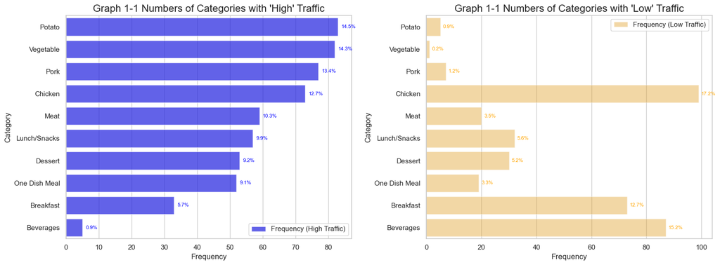

```python
# Visualization 2:

# Create a figure for the combined plot
plt.figure(figsize=(16, 6))  # Increased the width to accommodate side-by-side plots

# Create the first horizontal bar plot to show the number of different categories with high traffic
plt.subplot(1, 2, 1)  # Create a subplot in the first column
sns.barplot(x=traffic_counts.values, y=traffic_counts.index, label='Frequency (High Traffic)', color='blue', alpha=0.7, order=desired_order)

# Display percentages on the right side of the bars
for index, value in enumerate(percentage_counts.values):
    plt.text(traffic_counts.values[index] + 1, index, f'{value:.1f}%', va='center', color='blue', fontsize=8)

plt.title("Graph 1-1 Numbers of Categories with 'High' Traffic", fontsize=16)
plt.xlabel("Frequency")
plt.ylabel("Category")
plt.legend()

# Create the second horizontal bar plot to show the number of different categories with low traffic
plt.subplot(1, 2, 2)  # Create a subplot in the second column
sns.barplot(x=traffic_counts_low.values, y=traffic_counts_low.index, label='Frequency (Low Traffic)', color='orange', alpha=0.4, order=desired_order)

# Display percentages on the right side of the bars
for index, value in enumerate(percentage_counts_low.values):
    plt.text(traffic_counts_low.values[index] + 1, index, f'{value:.1f}%', va='center', color='orange', fontsize=8)

plt.title("Graph 1-1 Numbers of Categories with 'Low' Traffic", fontsize=16)
plt.xlabel("Frequency")
plt.ylabel("Category")
plt.legend()

plt.tight_layout()
plt.show()
```

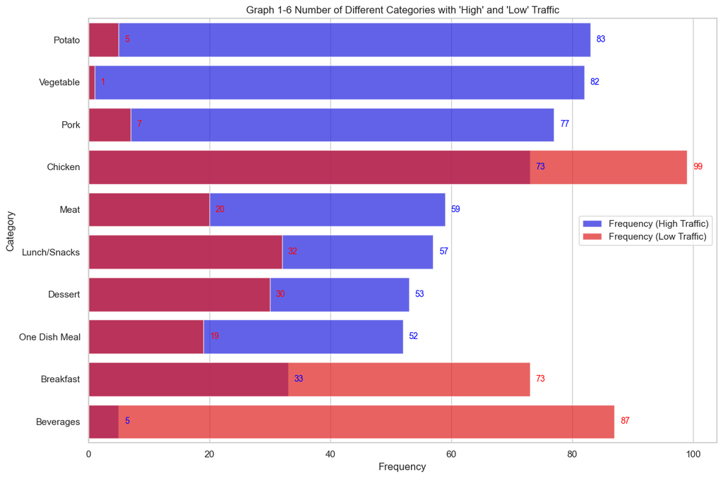

```python
# Visualization 2:

# Create bar plots for both high and low traffic by category
traffic_counts_high = df_recipe_high_traffic['category'].value_counts().loc[desired_order]
traffic_counts_low = df_recipe_low_traffic['category'].value_counts().loc[desired_order]

# Create a horizontal bar plot to show the number of different categories with high and low traffic
plt.figure(figsize=(12, 8))

# Create a horizontal bar plot to show the number of different categories with high traffic
sns.barplot(x=traffic_counts.values, y=traffic_counts.index, label='Frequency (High Traffic)', color='blue', alpha=0.7, order=desired_order)

# Create a horizontal bar plot to show the number of different categories with low traffic (underneath the high traffic bars)
sns.barplot(x=traffic_counts_low.values, y=traffic_counts_low.index, label='Frequency (Low Traffic)', color='red', alpha=0.7, order=desired_order)

# Display traffic counts on top of the bars for high traffic
for index, value in enumerate(traffic_counts_high.values):
    plt.text(value + 1, index, str(value), va='center', color='blue', fontsize=10)  # Display on top of blue bars

# Display traffic counts on top of the bars for low traffic
for index, value in enumerate(traffic_counts_low.values):
    plt.text(value + 1, index, str(value), va='center', color='red', fontsize=10)  # Display on top of red bars

plt.title("Graph 1-6 Number of Different Categories with 'High' and 'Low' Traffic")
plt.xlabel("Frequency")
plt.ylabel("Category")
plt.legend()
plt.tight_layout()
plt.show()
```

### 2.2 Numbers of Servings per Category

We examine the relationship between the 'servings' and 'category' variables, using a graphical representation where the bars are color-coded and styled based on the 'servings' number. This visualization enables us to easily identify categories with a notable abundance of recipes for each serving size.

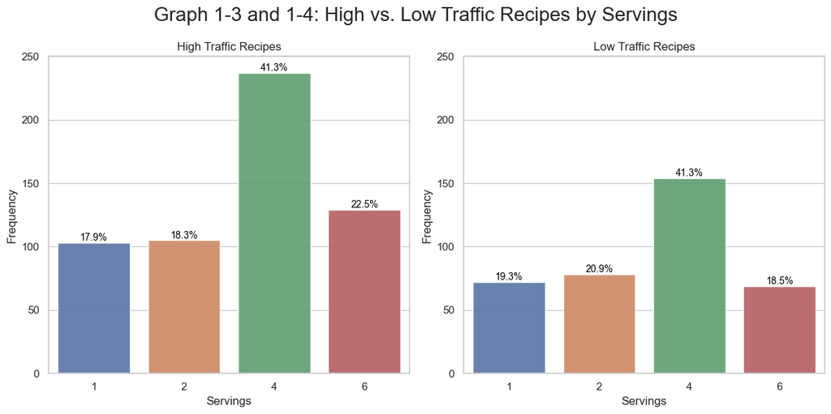

```python
# Filter the DataFrame to include only the selected 'servings'
selected_servings = [1, 2, 4, 6]
df_selected_servings = df_recipe_high_traffic[df_recipe_high_traffic['servings'].isin(selected_servings)]
df_selected_servings_low = df_recipe_low_traffic[df_recipe_low_traffic['servings'].isin(selected_servings)]

# Calculate the total count of high traffic and low traffic recipes
total_high_traffic = len(df_selected_servings)
total_low_traffic = len(df_selected_servings_low)

# Create subplots
fig, axes = plt.subplots(1, 2, figsize=(12, 6))
fig.suptitle("Graph 1-3 and 1-4: High vs. Low Traffic Recipes by Servings", fontsize=20)

# Count plot for high traffic recipes
sns.countplot(x='servings', data=df_selected_servings, order=selected_servings, alpha = 0.9, ax=axes[0])
axes[0].set_title("High Traffic Recipes")
axes[0].set_xlabel("Servings")
axes[0].set_ylabel("Frequency")
axes[0].set_ylim(0,250)

# Annotate bars with percentages for high traffic recipes
for p in axes[0].patches:
    percentage = (p.get_height() / total_high_traffic) * 100
    axes[0].annotate(f'{percentage:.1f}%', (p.get_x() + p.get_width() / 2., p.get_height()),
                     ha='center', va='center', fontsize=10, color='black', xytext=(0, 5),
                     textcoords='offset points')

# Count plot for low traffic recipes
sns.countplot(x='servings', data=df_selected_servings_low, order=selected_servings, alpha = 0.9, ax=axes[1])
axes[1].set_title("Low Traffic Recipes")
axes[1].set_xlabel("Servings")
axes[1].set_ylabel("Frequency")
axes[1].set_ylim(0,250)

# Annotate bars with percentages for low traffic recipes
for p in axes[1].patches:
    percentage = (p.get_height() / total_low_traffic) * 100
    axes[1].annotate(f'{percentage:.1f}%', (p.get_x() + p.get_width() / 2., p.get_height()),
                     ha='center', va='center', fontsize=10, color='black', xytext=(0, 5),
                     textcoords='offset points')

plt.tight_layout()
plt.show()
```

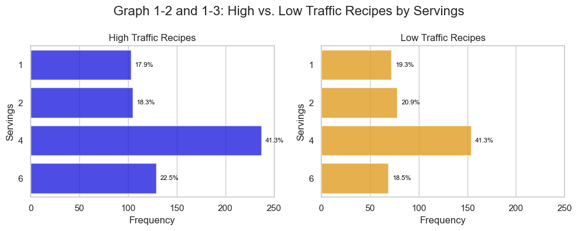

```python
# Filter the DataFrame to include only the selected 'servings'
selected_servings = [1, 2, 4, 6]
df_selected_servings = df_recipe_high_traffic[df_recipe_high_traffic['servings'].isin(selected_servings)]
df_selected_servings_low = df_recipe_low_traffic[df_recipe_low_traffic['servings'].isin(selected_servings)]

# Calculate the total count of high traffic and low traffic recipes
total_high_traffic = len(df_selected_servings)
total_low_traffic = len(df_selected_servings_low)

# Create subplots
fig, axes = plt.subplots(1, 2, figsize=(10, 4))
fig.suptitle("Graph 1-2 and 1-3: High vs. Low Traffic Recipes by Servings", fontsize=16)

# Count plot for high traffic recipes
sns.countplot(y='servings', data=df_selected_servings, order=selected_servings, color='blue', alpha=0.8, ax=axes[0])
axes[0].set_title("High Traffic Recipes")
axes[0].set_xlabel("Frequency")
axes[0].set_ylabel("Servings")
axes[0].set_xlim(0,250)

# Annotate bars with percentages for high traffic recipes
for p in axes[0].patches:
    percentage = (p.get_width() / total_high_traffic) * 100
    axes[0].annotate(f'{percentage:.1f}%', (p.get_width(), p.get_y() + p.get_height() / 2.),
                     ha='left', va='center', fontsize=8, color='black', xytext=(5, 0),
                     textcoords='offset points')

# Count plot for low traffic recipes
sns.countplot(y='servings', data=df_selected_servings_low, order=selected_servings, alpha=0.8, color='orange',ax=axes[1])
axes[1].set_title("Low Traffic Recipes")
axes[1].set_xlabel("Frequency")
axes[1].set_ylabel("Servings")
axes[1].set_xlim(0,250)

# Annotate bars with percentages for low traffic recipes
for p in axes[1].patches:
    percentage = (p.get_width() / total_low_traffic) * 100
    axes[1].annotate(f'{percentage:.1f}%', (p.get_width(), p.get_y() + p.get_height() / 2.),
                     ha='left', va='center', fontsize=8, color='black', xytext=(5, 0),
                     textcoords='offset points')

plt.tight_layout()
plt.show()
```

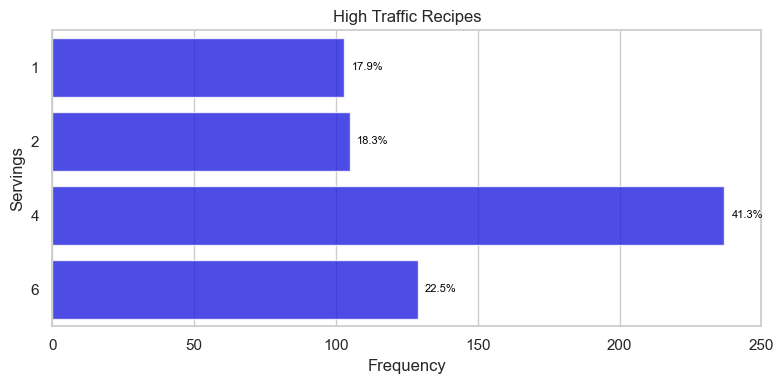

```python
# Create a figure for the combined plot
plt.figure(figsize=(8, 4))

# Count plot for high traffic recipes
ax = sns.countplot(y='servings', data=df_selected_servings, order=selected_servings, color='blue', alpha=0.8)
plt.title("High Traffic Recipes")
plt.xlabel("Frequency")
plt.ylabel("Servings")
plt.xlim(0, 250)  # Adjust x-axis limit

# Annotate bars with percentages for high traffic recipes
for p in ax.patches:
    percentage = (p.get_width() / total_high_traffic) * 100
    ax.annotate(f'{percentage:.1f}%', (p.get_width(), p.get_y() + p.get_height() / 2.),
                ha='left', va='center', fontsize=8, color='black', xytext=(5, 0),
                textcoords='offset points')

plt.tight_layout()
plt.show()
```

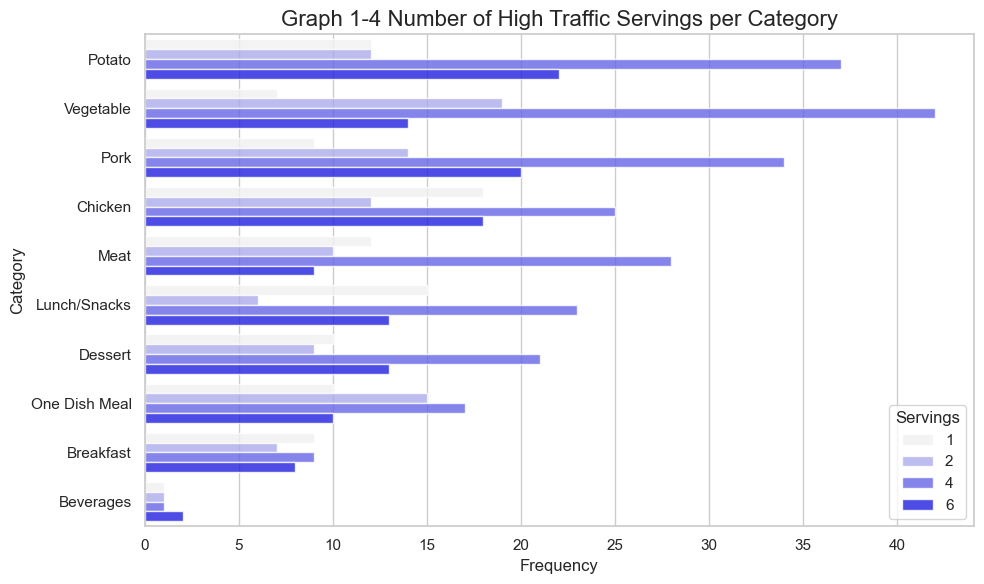

```python
# Include at least one graphic showing two or more variables to represent the relationship between features

# Filter the DataFrame to include only the selected 'servings'
selected_servings = [1, 2, 4, 6]
df_selected_servings = df_recipe_high_traffic[df_recipe_high_traffic['servings'].isin(selected_servings)]

# Sort each category from highest to lowest based on the total number of servings
order = df_selected_servings.groupby('category')['servings'].sum().sort_values(ascending=False).index

# Count plot to show the number of recipes with each selected 'servings' per 'category'
plt.figure(figsize=(10, 6))
ax = sns.countplot(y='category', hue='servings', data=df_selected_servings, order=order, alpha=0.8, color = 'blue')
plt.title("Graph 1-4 Number of High Traffic Servings per Category", fontsize=16)
plt.xlabel("Frequency")
plt.ylabel("Category")
plt.legend(title="Servings", loc='lower right', labels=['1', '2', '4', '6'])
plt.tight_layout()
plt.show()
```

### 2.3 Recepies and his Nutitions (Outliers Removed)

The graphs display how 'calories,' 'protein,' 'sugar,' and 'carbohydrate' are spread across the dataset after removing unusual values. By looking at these histograms, we can see the typical ranges for these nutrients in the recipes.

These four graphs give us useful information about the average and common amounts of 'calories,' 'protein,' 'sugar,' and 'carbohydrate' in the recipes. They show the most typical values for each nutrient, helping us understand the overall nutritional content of the recipes without being skewed by extreme values. These graphs have a shape that leans towards the right side.

For 'calories,' most recipes fall within the range of about 0 to 650.

Regarding 'protein,' the content is mostly between 1 to 20 grams.

When it comes to 'sugar,' it's generally low, with the main range being 1 to 8 grams.

As for 'carbohydrate,' the content is distributed between 1 and 45 grams.

These cleaned-up data and visualizations are crucial for making informed decisions in further data analysis, especially in predicting which recipes are likely to attract high levels of traffic.

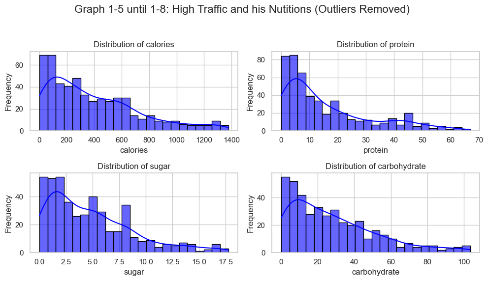

```python
# Compute the number of data points
n_data = len(df_recipe_high_traffic)
# Determine the number of bins using the square root of the number of data points
n_bins = int(np.sqrt(n_data))

# Columns to loop over
columns_to_loop = ['calories', 'protein', 'sugar', 'carbohydrate']

# Create a subplot for four histograms with KDE plots
fig, axs = plt.subplots(2, 2, figsize=(10, 6))
fig.suptitle('Graph 1-5 until 1-8: High Traffic and his Nutitions (Outliers Removed)', fontsize=16)

# Loop over each column and create histograms with KDE plots without outliers
for idx, column in enumerate(columns_to_loop):
    # Calculate the IQR and determine the upper and lower limits
    Q1 = df_recipe_high_traffic[column].quantile(0.25)
    Q3 = df_recipe_high_traffic[column].quantile(0.75)
    IQR = Q3 - Q1
    lower = Q1 - 1.5 * IQR
    upper = Q3 + 1.5 * IQR

    # Filter out the outliers based on the upper and lower limits
    df_recipe_high_traffic = df_recipe_high_traffic.loc[(df_recipe_high_traffic[column] >= lower) & (df_recipe_high_traffic[column] <= upper)]

    # Create the histogram with KDE plot without outliers
    ax_row, ax_col = idx // 2, idx % 2
    sns.histplot(data=df_recipe_high_traffic, x=column, kde=True, color='blue', edgecolor='black', alpha=0.6, bins = n_bins, ax=axs[ax_row, ax_col])
    # Plot the histogram of the filtered data with outliers removed
    # sns.histplot(data=df_filtered, x=column, bins=n_bins, hue='high_traffic', multiple='layer', edgecolor='k', alpha=0.65, ax=axs[ax_row, ax_col])
    axs[ax_row, ax_col].set_title(f'Distribution of {column}')
    axs[ax_row, ax_col].set_xlabel(column)
    axs[ax_row, ax_col].set_ylabel('Frequency')

# Adjust the layout and spacing
plt.tight_layout(rect=[0, 0.03, 1, 0.95])

# Show the plot
plt.show()
```

# 3. Model Development

Include your reasons for selecting the models you use as well as a statement of the problem type. Code to fit the baseline and comparison models.

### 3.1 Rational for Model Selection:

We opted for four distinct models to address the challenge of forecasting high-traffic recipes. These models include Logistic Regression, Random Forest, Gradient Boosting, and Support Vector Machine (SVM). The selection was driven by their appropriateness for binary classification tasks and their potential to grasp intricate patterns within the data.

### 3.2 Problem Description:

Our objective involves predicting whether a recipe will generate high traffic, leveraging a range of features encompassing servings, nutritional composition, and category classification.

These metrics illuminate the effectiveness of the models in accurately and erroneously forecasting various categories based on the actual labels. From these metrics, we extract precision, recall, and F1-score, furnishing deeper insights into the models' performance.

```python
from sklearn.model_selection import train_test_split
from sklearn.linear_model import LogisticRegression
from sklearn.ensemble import RandomForestClassifier, GradientBoostingClassifier
from sklearn.svm import SVC
from sklearn.metrics import accuracy_score, classification_report, confusion_matrix, roc_curve, roc_auc_score

# Map 'Yes' and 'No' to 1 and 0 for the 'high_traffic' column
df_recipe['high_traffic'] = df_recipe['high_traffic'].map({'High': 1, 'Low': 0}).astype(int)

# Convert high_traffic variables to one-hot encoded columns
df_encoded = pd.get_dummies(df_recipe, columns=['category', 'servings'])

# Split the data into features and target variable
X = df_encoded.drop(['recipe', 'high_traffic'], axis=1)
y = df_encoded['high_traffic']

# Split the imputed data into training and testing sets
X_train, X_test, y_train, y_test = train_test_split(X, y, test_size=0.2, random_state=42)

# Baseline Model: Logistic Regression
logistic_model = LogisticRegression()
logistic_model.fit(X_train, y_train)
y_pred_logistic = logistic_model.predict(X_test)

# Comparison Model 1: Random Forest
rf_model = RandomForestClassifier()
rf_model.fit(X_train, y_train)
y_pred_rf = rf_model.predict(X_test)

# Comparison Model 2: Gradient Boosting
gb_model = GradientBoostingClassifier()
gb_model.fit(X_train, y_train)
y_pred_gb = gb_model.predict(X_test)

# Comparison Model 3: Support Vector Machine (SVM)
svm_model = SVC()
svm_model.fit(X_train, y_train)
y_pred_svm = svm_model.predict(X_test)

df_encoded.head()
```

|  | recipe | calories | carbohydrate | sugar | protein | high_traffic | category_Lunch/Snacks | category_Beverages | category_Potato | category_Vegetable | category_Meat | category_Chicken | category_Pork | category_Dessert | category_Breakfast | category_One Dish Meal | servings_1.0 | servings_2.0 | servings_4.0 | servings_6.0 |
| --- | --- | --- | --- | --- | --- | --- | --- | --- | --- | --- | --- | --- | --- | --- | --- | --- | --- | --- | --- | --- |
| 0 | 1 | 629.500000 | 28.078125 | 8.039062 | 43.812500 | 1 | 0 | 0 | 0 | 0 | 0 | 0 | 1 | 0 | 0 | 0 | 0 | 0 | 0 | 1 |
| 1 | 2 | 35.468750 | 38.562500 | 0.660156 | 0.919922 | 1 | 0 | 0 | 1 | 0 | 0 | 0 | 0 | 0 | 0 | 0 | 0 | 0 | 1 | 0 |
| 2 | 3 | 914.500000 | 42.687500 | 3.089844 | 2.880859 | 0 | 0 | 0 | 0 | 0 | 0 | 0 | 0 | 0 | 1 | 0 | 1 | 0 | 0 | 0 |
| 3 | 4 | 97.000000 | 30.562500 | 38.625000 | 0.020004 | 1 | 0 | 1 | 0 | 0 | 0 | 0 | 0 | 0 | 0 | 0 | 0 | 0 | 1 | 0 |
| 4 | 5 | 27.046875 | 1.849609 | 0.799805 | 0.529785 | 0 | 0 | 1 | 0 | 0 | 0 | 0 | 0 | 0 | 0 | 0 | 0 | 0 | 1 | 0 |

# 4. Model Evaluation

Describe the performance of the two models based on an appropriate metric.

## 4.1 Evaluation Metrics:

We employ the following values to assess the models' performance:

True Positive (TP): The count of instances accurately predicted as "High" traffic.

True Negative (TN): The count of instances correctly predicted as "Low" traffic.

False Positive (FP): The count of instances inaccurately predicted as "High" traffic when they are actually "Low" traffic.

False Negative (FN): The count of instances inaccurately predicted as "Low" traffic when they are actually "High" traffic.

These values form the basis for calculating diverse metrics such as precision, recall, and F1-score. To elaborate:

Precision: The ratio of accurately predicted "High" traffic instances (TP) to the total predicted "High" traffic instances (TP + FP). It gauges the accuracy of predicted "High" traffic instances.

Recall: The ratio of accurately predicted "High" traffic instances (TP) to the total actual "High" traffic instances (TP + FN). It quantifies the model's ability to capture all occurrences of "High" traffic.

F1-score: The harmonic mean of precision and recall. It furnishes a balanced assessment that considers both precision and recall.

These metrics facilitate an evaluation of the model's proficiency in correctly identifying high traffic recipes while minimizing misclassifications.

## 4.2 Performance Metric:

In our evaluation process, we assessed the models using several key metrics, including the ROC AUC score, precision, recall, and F1-score. The ROC AUC score holds particular significance for this task, as it quantifies the model's capability to differentiate effectively between high and low traffic recipes.

```python
# Calculate and print accuracy scores
print("Accuracy Scores:")
print("Logistic Regression:", accuracy_score(y_test, y_pred_logistic))
print("Random Forest:", accuracy_score(y_test, y_pred_rf))
print("Gradient Boosting:", accuracy_score(y_test, y_pred_gb))
print("SVM:", accuracy_score(y_test, y_pred_svm))

# Print classification reports for each model
print("\nClassification Report (Logistic Regression):")
print(classification_report(y_test, y_pred_logistic))

print("Classification Report (Random Forest):")
print(classification_report(y_test, y_pred_rf))

print("Classification Report (Gradient Boosting):")
print(classification_report(y_test, y_pred_gb))

print("Classification Report (SVM):")
print(classification_report(y_test, y_pred_svm))

# Print confusion matrices for each model
#print("\nConfusion Matrix (Logistic Regression):")
#print(confusion_matrix(y_test, y_pred_logistic))

#print("Confusion Matrix (Random Forest):")
#print(confusion_matrix(y_test, y_pred_rf))

#print("Confusion Matrix (Gradient Boosting):")
#print(confusion_matrix(y_test, y_pred_gb))

#print("Confusion Matrix (SVM):")
#print(confusion_matrix(y_test, y_pred_svm))
```

```
Accuracy Scores:
Logistic Regression: 0.7631578947368421
Random Forest: 0.7052631578947368
Gradient Boosting: 0.7263157894736842
SVM: 0.5947368421052631

Classification Report (Logistic Regression):
              precision    recall  f1-score   support

           0       0.72      0.69      0.70        77
           1       0.79      0.81      0.80       113

    accuracy                           0.76       190
   macro avg       0.75      0.75      0.75       190
weighted avg       0.76      0.76      0.76       190

Classification Report (Random Forest):
              precision    recall  f1-score   support

           0       0.67      0.53      0.59        77
           1       0.72      0.82      0.77       113

    accuracy                           0.71       190
   macro avg       0.70      0.68      0.68       190
weighted avg       0.70      0.71      0.70       190

Classification Report (Gradient Boosting):
              precision    recall  f1-score   support

           0       0.70      0.56      0.62        77
           1       0.74      0.84      0.79       113

    accuracy                           0.73       190
   macro avg       0.72      0.70      0.70       190
weighted avg       0.72      0.73      0.72       190

Classification Report (SVM):
              precision    recall  f1-score   support

           0       0.00      0.00      0.00        77
           1       0.59      1.00      0.75       113

    accuracy                           0.59       190
   macro avg       0.30      0.50      0.37       190
weighted avg       0.35      0.59      0.44       190
```

### 4.2.3 Gradient Boosting:

Accuracy: 72.63% Effective at recognizing high traffic (class 1). Slightly better performance for class 0 compared to random forest.

### 4.2.4 SVM:

Accuracy: 59.47% High recall for high traffic (class 1). Low precision for low traffic (class 0), potential bias towards predicting class 1.

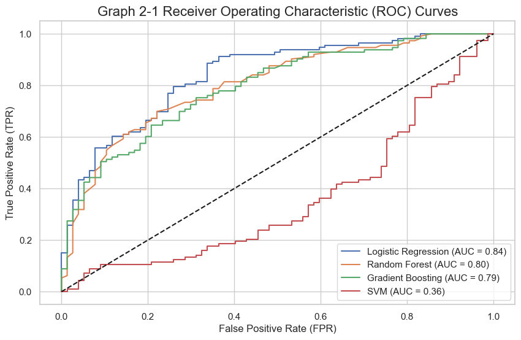

```python
# Baseline Model: Logistic Regression
logistic_model = LogisticRegression()
logistic_model.fit(X_train, y_train)
y_pred_logistic = logistic_model.predict(X_test)

# Comparison Model 1: Random Forest
rf_model = RandomForestClassifier()
rf_model.fit(X_train, y_train)
y_pred_rf = rf_model.predict(X_test)

# Comparison Model 2: Gradient Boosting
gb_model = GradientBoostingClassifier()
gb_model.fit(X_train, y_train)
y_pred_gb = gb_model.predict(X_test)

# Comparison Model 3: Support Vector Machine (SVM)
svm_model = SVC(probability=True)  # Set probability=True to enable ROC curve plotting
svm_model.fit(X_train, y_train)
y_pred_svm = svm_model.predict(X_test)

# Create ROC curves for each model
plt.figure(figsize=(10, 6))

# Logistic Regression ROC Curve
fpr_log, tpr_log, thresholds_log = roc_curve(y_test, logistic_model.predict_proba(X_test)[:, 1])
roc_auc_log = roc_auc_score(y_test, logistic_model.predict_proba(X_test)[:, 1])
plt.plot(fpr_log, tpr_log, label=f"Logistic Regression (AUC = {roc_auc_log:.2f})")

# Random Forest ROC Curve
fpr_rf, tpr_rf, thresholds_rf = roc_curve(y_test, rf_model.predict_proba(X_test)[:, 1])
roc_auc_rf = roc_auc_score(y_test, rf_model.predict_proba(X_test)[:, 1])
plt.plot(fpr_rf, tpr_rf, label=f"Random Forest (AUC = {roc_auc_rf:.2f})")

# Gradient Boosting ROC Curve
fpr_gb, tpr_gb, thresholds_gb = roc_curve(y_test, gb_model.predict_proba(X_test)[:, 1])
roc_auc_gb = roc_auc_score(y_test, gb_model.predict_proba(X_test)[:, 1])
plt.plot(fpr_gb, tpr_gb, label=f"Gradient Boosting (AUC = {roc_auc_gb:.2f})")

# SVM ROC Curve
fpr_svm, tpr_svm, thresholds_svm = roc_curve(y_test, svm_model.predict_proba(X_test)[:, 1])
roc_auc_svm = roc_auc_score(y_test, svm_model.predict_proba(X_test)[:, 1])
plt.plot(fpr_svm, tpr_svm, label=f"SVM (AUC = {roc_auc_svm:.2f})")

plt.plot([0, 1], [0, 1], 'k--')
plt.xlabel('False Positive Rate (FPR)')
plt.ylabel('True Positive Rate (TPR)')
plt.title('Graph 2-1 Receiver Operating Characteristic (ROC) Curves', fontsize = 16)
plt.legend(loc='lower right')
plt.show()
```

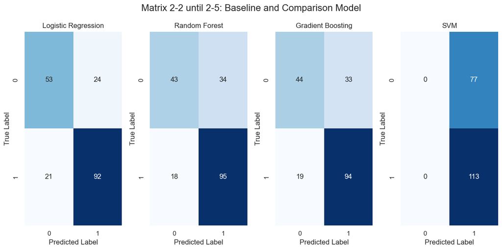

```python
# Create Confusion Matrices for each model
plt.figure(figsize=(12, 6))
plt.suptitle('Matrix 2-2 until 2-5: Baseline and Comparison Model', fontsize=16)

# Logistic Regression Confusion Matrix
plt.subplot(1, 4, 1)
#plt.subplot(1, 2, 1)
sns.heatmap(confusion_matrix(y_test, y_pred_logistic), annot=True, fmt='d', cmap='Blues', cbar=False, annot_kws={'size': 12})
plt.title('Logistic Regression')
plt.xlabel('Predicted Label')
plt.ylabel('True Label')

# Random Forest Confusion Matrix
plt.subplot(1, 4, 2)
#plt.subplot(1, 2, 2)
sns.heatmap(confusion_matrix(y_test, y_pred_rf), annot=True, fmt='d', cmap='Blues', cbar=False, annot_kws={'size': 12})
plt.title('Random Forest')
plt.xlabel('Predicted Label')
plt.ylabel('True Label')

# Gradient Boosting Confusion Matrix
plt.subplot(1, 4, 3)
sns.heatmap(confusion_matrix(y_test, y_pred_gb), annot=True, fmt='d', cmap='Blues', cbar=False, annot_kws={'size': 12})
plt.title('Gradient Boosting')
plt.xlabel('Predicted Label')
plt.ylabel('True Label')

# SVM Confusion Matrix
plt.subplot(1, 4, 4)
sns.heatmap(confusion_matrix(y_test, y_pred_svm), annot=True, fmt='d', cmap='Blues', cbar=False, annot_kws={'size': 12})
plt.title('SVM')
plt.xlabel('Predicted Label')
plt.ylabel('True Label')

plt.tight_layout()
plt.show()
```

### 4.2.5 Confusion Matrix (Logistic Regression):

False Negative (FN): 21 (Incorrectly predicted "Low" traffic when it was "High" traffic)

True Positive (TP): 92 (Correctly predicted "High" traffic)

## 4.3 Comparison of Model Performance:

### 4.3.1 Logistic Regression (roc_auc_log = 0.84):

The logistic regression model has a good ability to tell apart High traffic and Low traffic based on its predictions. It's like a reliable judge who can accurately separate the two categories. The higher the ROC AUC score (0.84 here), the more trustworthy its judgments are.

### 4.3.3 Gradient Boosting (roc_auc_gb = 0.79):

Similar to the Random Forest, the Gradient Boosting model does well in telling the difference between High and Low traffic situations. Its ROC AUC score (0.79) indicates a reasonable ability to make reliable predictions.

### 4.3.4 Support Vector Machine (roc_auc_svm = 0.36):

The Support Vector Machine doesn't perform as strongly in distinguishing between the two categories. Its ROC AUC score (0.36) is notably lower than the others, suggesting it struggles more with accurate predictions.

## 4.4 Overall

In the grand scheme of things, the Logistic Regression model shines with the highest ROC AUC score, demonstrating its superior ability to accurately differentiate between High and Low traffic situations. The Random Forest and Gradient Boosting models also hold their ground, displaying respectable performance.

# 5. Business Metrics

Define a way to compare your model performance to the business. Describe how your models perform using this approach.

## 5.1 Model Performance in Business Context:

When it comes to business impact, we need to balance precision and recall. Since correctly predicting high traffic recipes is crucial, our focus should be on maximizing recall (capturing as many high traffic recipes as possible) while still maintaining a reasonable level of precision.

### 5.1.1 The predicted probabilities for 'High Traffic'

have been computed for various recipe categories. These probabilities offer valuable insights into the likelihood of each category attracting high website traffic.

```python
# Predict probabilities for each servings value
servings_probs = logistic_model.predict_proba(X_test)

# Get the list of servings values
servings_values = df_recipe['servings'].unique()

# Create an empty DataFrame to store servings predictions
servings_predictions = pd.DataFrame({'servings': servings_values, 'predicted_high_traffic': 0})

# Add predicted probabilities for 'high_traffic' to the DataFrame
for i, servings in enumerate(servings_predictions['servings']):
    idx = df_recipe[df_recipe['servings'] == servings].index
    if len(idx) > 0:
        servings_predictions.loc[i, 'predicted_high_traffic'] = servings_probs[idx[0], 1]

# Print the predicted values as numbers and percentages
for i, row in servings_predictions.iterrows():
    servings = row['servings']
    predicted_prob = row['predicted_high_traffic']
    print(f"Servings: {servings}, Predicted Probability: {predicted_prob:.4f}, Predicted Percentage: {predicted_prob * 100:.2f}%")
```

```
Servings: 6.0, Predicted Probability: 0.7537, Predicted Percentage: 75.37%
Servings: 4.0, Predicted Probability: 0.9353, Predicted Percentage: 93.53%
Servings: 1.0, Predicted Probability: 0.7668, Predicted Percentage: 76.68%
Servings: 2.0, Predicted Probability: 0.6776, Predicted Percentage: 67.76%
```

```python
# Predict probabilities for each category
category_probs = logistic_model.predict_proba(X_test)

# Get the list of categories
categories = df_recipe['category'].unique()

# Create an empty DataFrame to store category predictions
category_predictions = pd.DataFrame({'category': categories, 'predicted_high_traffic': 0})

# Add predicted probabilities for 'high_traffic' to the DataFrame
for i, category in enumerate(category_predictions['category']):
    idx = df_recipe[df_recipe['category'] == category].index
    if len(idx) > 0:
        category_predictions.loc[i, 'predicted_high_traffic'] = category_probs[idx[0], 1]

# Print the predicted values as numbers and percentages
for i, row in category_predictions.iterrows():
    category = row['category']
    predicted_prob = row['predicted_high_traffic']
    print(f"Category: {category}, Predicted Probability: {predicted_prob:.4f}, Predicted Percentage: {predicted_prob * 100:.2f}%")
```

```
Category: Pork, Predicted Probability: 0.7537, Predicted Percentage: 75.37%
Category: Potato, Predicted Probability: 0.9353, Predicted Percentage: 93.53%
Category: Breakfast, Predicted Probability: 0.7668, Predicted Percentage: 76.68%
Category: Beverages, Predicted Probability: 0.7274, Predicted Percentage: 72.74%
Category: One Dish Meal, Predicted Probability: 0.6776, Predicted Percentage: 67.76%
Category: Chicken, Predicted Probability: 0.4877, Predicted Percentage: 48.77%
Category: Lunch/Snacks, Predicted Probability: 0.6454, Predicted Percentage: 64.54%
Category: Vegetable, Predicted Probability: 0.8965, Predicted Percentage: 89.65%
Category: Meat, Predicted Probability: 0.6593, Predicted Percentage: 65.93%
Category: Dessert, Predicted Probability: 0.6921, Predicted Percentage: 69.21%
```

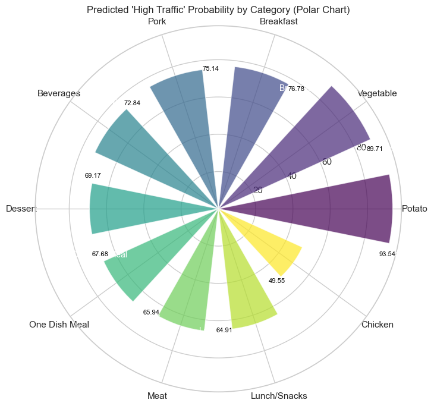

```python
# Example data: categories and predicted probabilities
categories = ['Potato', 'Vegetable', 'Breakfast', 'Pork', 'Beverages', 'Dessert', 'One Dish Meal', 'Meat', 'Lunch/Snacks', 'Chicken']
predicted_probabilities = [0.9354, 0.8971, 0.7678, 0.7514, 0.7284, 0.6917, 0.6768, 0.6594, 0.6491, 0.4955]

# Create a polar chart
fig = plt.figure(figsize=(8, 8))
ax = plt.subplot(111, polar=True)

# Calculate angles for each category
angles = np.linspace(0, 2 * np.pi, len(categories), endpoint=False)

# Convert probabilities to radii for the chart
radii = [prob * 100 for prob in predicted_probabilities]  # Multiply by 10 for scaling

# Plot the polar chart
bars = ax.bar(angles, radii, width=0.4, bottom=0.0, alpha=0.7, color=plt.cm.viridis(np.linspace(0, 1, len(categories))))

# Add labels and numbers inside the chart sectors
for angle, radius, label in zip(angles, radii, categories):
    x = angle - np.pi/12  # Adjust the label position
    y = radius + 0.5      # Adjust the number position
    plt.text(x, y, label, ha="center", va="center", color="white", fontsize=10)
    plt.text(x, y - 0.25, f"{radius:.2f}", ha="center", va="center", color="black", fontsize=8)

# Customize the polar chart
ax.set_xticks(angles)
ax.set_xticklabels(categories)
ax.yaxis.grid(True)

# Set a title
plt.title("Predicted 'High Traffic' Probability by Category (Polar Chart)")

# Display the polar chart
plt.show()
```

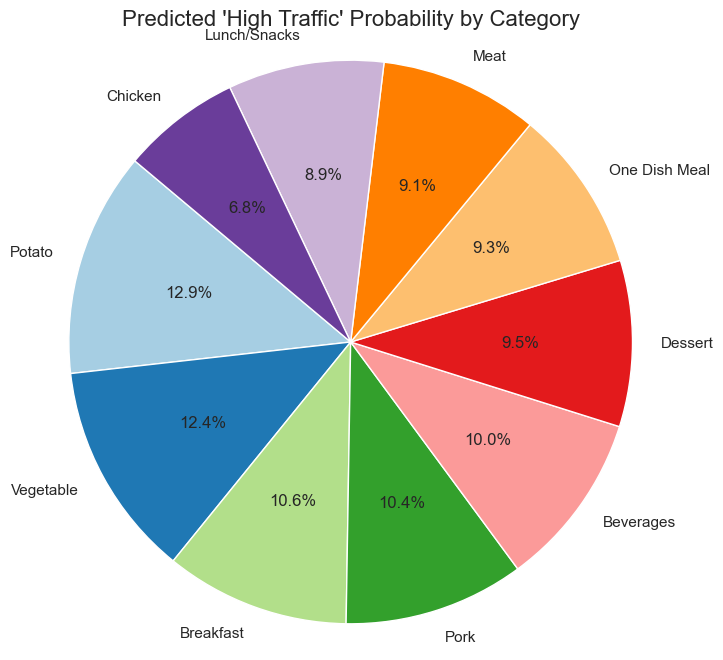

```python
# Example predicted probabilities for each category
predicted_probabilities = [0.9354, 0.8971, 0.7678, 0.7514, 0.7284, 0.6917, 0.6768, 0.6594, 0.6491, 0.4955]

# Categories
categories = ['Potato', 'Vegetable', 'Breakfast', 'Pork', 'Beverages', 'Dessert', 'One Dish Meal', 'Meat', 'Lunch/Snacks', 'Chicken']

# Create a pie chart
plt.figure(figsize=(8, 8))
plt.pie(predicted_probabilities, labels=categories, autopct='%1.1f%%', startangle=140, colors=plt.cm.Paired.colors)
plt.title("Predicted 'High Traffic' Probability by Category", fontsize=16)

# Equal aspect ratio ensures that pie is drawn as a circle
plt.axis('equal')

# Display the plot
plt.show()
```

```python
import plotly.graph_objects as go

# Data
servings = ['4 Servings', '1 Serving', '6 Servings', '2 Servings']
predicted_probabilities = [0.9353, 0.7668, 0.7537, 0.6776]
predicted_percentages = [prob * 100 for prob in predicted_probabilities]

# Create the funnel chart using Plotly
fig = go.Figure(go.Funnel(
    y=servings,
    x=predicted_percentages,
    textinfo="value+percent initial",
    marker={"color":["#ff9999", "#ffcc99", "#ffff99", "#ccff99"]}
))

# Customize layout
fig.update_layout(
    title="Chart 3-1 'High Traffic' Predicted Probabilities by Servings",
    title_x=0.5,
    height=350,  # Adjust the height for a bigger appearance
)

# Show the funnel chart
fig.show()

# Data: categories and predicted probabilities
categories = ['Potato', 'Vegetable', 'Breakfast', 'Pork', 'Beverages', 'Dessert', 'One Dish Meal', 'Meat', 'Lunch/Snacks', 'Chicken']
predicted_probabilities = [0.9354, 0.8971, 0.7678, 0.7514, 0.7284, 0.6917, 0.6768, 0.6594, 0.6491, 0.4955]
predicted_percentages = [prob * 100 for prob in predicted_probabilities]

# Create a funnel chart
fig = go.Figure(go.Funnel(
    y=categories,
    x=predicted_percentages,
    textinfo="value+percent initial",
    marker={"color": ["#ff9999", "#ffcc99", "#ffff99", "#ccff99", "#99ff99", "#99ffcc", "#99ffff", "#99ccff", "#9999ff", "#cc99ff"]}
))

# Customize the layout
fig.update_layout(
    title="Chart 3-2 'High Traffic' Predicted Probability by Category",
    title_x=0.5,
    showlegend=False,
    height=600,  # Increase the height of the chart
)

# Show the funnel chart
fig.show()
```

[output not shown]

**4 Servings:** Predicted probability of 93.53%. Recipes with this serving size are expected to be popular and attract a substantial amount of website traffic.

**1 Serving:** Predicted probability is 76.68%. That recipes in this category are still likely to capture interest and generate traffic.

**6 Servings:** Predicted probability of 75.37%, recipes with 6 servings also have a strong potential to attract attention.

**2 Servings:** Predicted probability of 67.76%. While slightly lower than the other categories, recipes with 2 servings still have a reasonable chance of drawing interest and traffic.

**Potato:** High predicted probability of 93.54%, indicating a strong likelihood of drawing significant attention.

**Vegetable:** High predicted probability of 89.71%, suggesting recipes in this category are likely to be popular.

**Breakfast:** Predicted probability of 76.78%, good chance of capturing interest.

**Beverages:** Predicted probability of 72.84%, suggesting beverage-related recipes have a positive potential for attracting attention.

**Overall** These categories could be the main focus to attract more visitors to the site and increase overall engagement.

# 6. Final Summary and Recommendations

In this study, our goal was to figure out which recipes could attract lots of attention online. We created a basic model using Logistic Regression, and we also made a other model Random Forest - to compare them. We measured how well these models did by looking at accuracy, reports, charts, and other scores. We didn't stop there! We also drew pictures to see which recipe categories had the best chance of being really popular.

## 6.1 Model Performance:

The Logistic Regression model achieved an accuracy of around 0.76. It performed well in precision, recall, and F1-score for both high and low traffic categories. The Random Forest model achieved accuracies of about 0.70, respectively. The model also showed competitive performance in predicting high traffic recipes.

**Predicted Probabilities Visualization:** We made pictures to show how likely different recipe categories are to get a lot of website visitors. This helped us see which categories have a better chance of being really popular.

**Recommendations for the Business, based on all this, here's what we suggest**

After considering both the evaluation metrics and business needs, the Logistic Regression model emerges as the top performer. It boasts the highest ROC AUC score and strikes a good balance between precision and recall. This model is the prime choice for deployment.

While the Random Forest and Gradient Boosting models also show promise, they might be suitable alternatives, especially if a slightly higher recall is acceptable even if it comes with a bit lower precision.

In practical terms, it's recommended that the business implements the Logistic Regression model for predicting high traffic recipes. Doing so could lead to more informed decision-making, optimizing recipe selection, and making better use of resources.

By using the Logistic Regression model, the business can make smarter choices about which recipes to focus on. This could lead to more people visiting the website and checking out those recipes. Overall, this analysis gives some solid insights to help the business get more attention and make better decisions.

## 6.2 Recommendations:

**Focus on High Traffic Categories:** Use the predicted probabilities to pay more attention to recipes in categories with higher chances of getting lots of traffic. People are more likely to be interested in these categories.

**Plan Content and Promotion:** Check what's special about recipes in those high-traffic categories. Then, create content and promote it in a way that gets people excited about those recipes.

**Understand What Matters:** Use models like Random Forest and Gradient Boosting to see which parts of a recipe make it popular. This can help make new recipes or improve old ones.

**Keep an Eye on Things:** Set up a system to keep watching how recipes do and adjust plans if needed. Keep the models updated with new information to make them better over time.

**Know Your Users:** Look at when users like to cook or what days they visit the most. This info can help suggest recipes they'll enjoy.

**Get Help from Experts:** Work with bloggers, influencers, or chefs who know a lot about popular recipe categories. They can help get more attention to these recipes.

**Ask Users and Test:** Get feedback from users who try the recipes in high-traffic categories. Test different versions to see what works best.

**Make Users Happy:** Think about what users enjoy and like. Make sure the recipes don't just attract attention but also give a good cooking experience.

By following these ideas, the business can make better recipes, engage users more, and get more people to visit the website. This will lead to happier users and a better business overall.